DS 6030 | Fall 2024 | University of Virginia

# Homework #9: Feature Importance

Author

**Rohan Shroff**

Published

November 14, 2024

# Required R packages and Directories

```r
dir_data = 'https://mdporter.github.io/teaching/data/' # data directory
library(tidyverse) # functions for data manipulation
library(ranger)
```

# Problem 1: Permutation Feature Importance

Vanderbilt Biostats has collected data on Titanic survivors (https://hbiostat.org/data/). I have done some simple processing and split into a training and test sets.

- titanic_train.csv
- titanic_test.csv

We are going to use this data to investigate feature importance. Use `Class`, `Sex`, `Age`, `Fare`, `sibsp` (number of siblings or spouse on board), `parch` (number of parents or children on board), and `Joined` (city where passenger boarded) for the predictor variables (features) and `Survived` as the outcome variable.

## a. Load the titanic traning and testing data

**Solution**

```r
df_train <- read.csv('titanic_train.csv')
df_test <- read.csv('titanic_test.csv')


df_train <- df_train[c("Class","Sex","Age", "Fare", "sibsp", "parch", "Joined", "Survived")]
df_test <- df_test[c("Class","Sex","Age", "Fare", "sibsp", "parch", "Joined", "Survived")]

df_train <- na.omit(df_train)
df_test <- na.omit(df_test)
```

## b. Method 1: Built-in importance scores

Fit a tree ensemble model (e.g., Random Forest, boosted tree) on the training data. You are free to use any method to select the tuning parameters.

Report the built-in feature importance scores and produce a barplot with feature on the x-axis and importance on the y-axis.

**Solution**

```r
set.seed(1912)

mtry_vals <- seq(1,3,1)
bucket_vals <- seq(1,5,1)

results_df <- data.frame(bucket=integer(), mtry = integer(), MSE=numeric())


for (i in mtry_vals) {

  for (b in bucket_vals){

    rf_1 <- ranger(Survived~., num.trees=500, mtry = i, min.bucket = b, data=df_train)
    rf_2 <- ranger(Survived~., num.trees=500, mtry = i, min.bucket = b, data=df_train)
    rf_3 <- ranger(Survived~., num.trees=500, mtry = i, min.bucket = b, data=df_train)


    MSE <- mean(c(rf_1$prediction.error, rf_2$prediction.error, rf_3$prediction.error))

    new_row <- data.frame(bucket=b, mtry=i, MSE=MSE)

    results_df <- rbind(results_df, new_row)

  }

}
```

```r
results_df[which.min(results_df$MSE), ]
```

```
  bucket mtry   MSE
7      2    2 0.135
```

```r
# The best paramaters are bucket size of 2 and mtry of 2.
```

```r
# Fitting tuned model
rf_model <- ranger(Survived~.,num.trees=500, mtry=2, min.bucket=2,importance = "impurity", data=df_train)
rf_model$prediction.error
```

```
[1] 0.135
```

```r
# Variable importance
import_df <- data.frame(Feature=names(rf_model$variable.importance), Importance = rf_model$variable.importance)
import_df
```

```
       Feature Importance
Class    Class      16.62
Sex        Sex      55.90
Age        Age      24.42
Fare      Fare      29.71
sibsp    sibsp       6.74
parch    parch       6.51
Joined  Joined       7.13
```

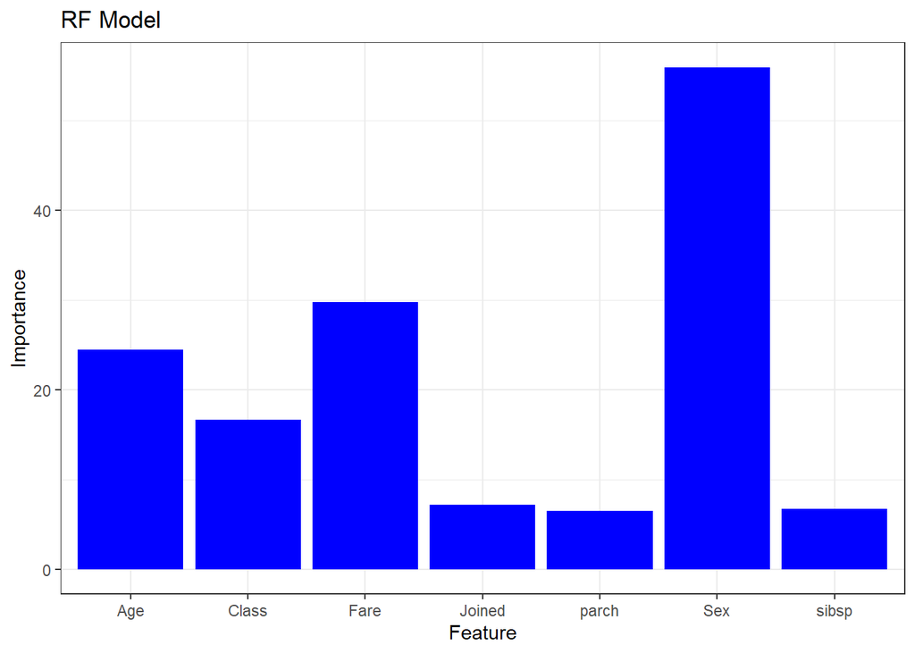

```r
ggplot(data = import_df, aes(x=Feature, y = Importance)) +
  geom_col(fill='blue') +
  labs(title = 'RF Model', x = 'Feature', y = 'Importance')
```

## c. Performance

Report the performance of the model fit from (a.) on the test data. Use the log-loss (where $M$ is the size of the test data):
$$\text{log-loss}(\hat{p}) = - \frac{1}{M} \sum_{i=1}^m [y_i \log \, \hat{p}_i + (1 - y_i) \log \, (1 - \hat{p}_i)]$$

**Solution**

```r
test_pred <- predict(rf_model, data = df_test)
```

```r
log_loss_df <- data.frame(df_test$Survived, test_pred$pred)
log_loss_df['eq'] <- (log_loss_df$df_test.Survived * log(log_loss_df$test_pred.pred)) + ((1-log_loss_df$df_test.Survived)*log(1-log_loss_df$test_pred.pred))

log_loss_c <- (-1/nrow(df_test) )* sum(log_loss_df$eq)
log_loss_c
```

```
[1] 0.41
```

## d. Method 2: Permute *after* fitting

Use the fitted model from question (a.) to perform permutation feature importance. Shuffle/permute each variable individually on the *test set* before making predictions. Record the loss. Repeat $M=10$ times and produce a boxplot of the change in loss (change from reported loss from part b.).

**Solution**

```r
avg_loss <- list()

for (i in 1:7){

  loss_change_list = vector()

  for (m in 1:10) {

    df_test_mod <- df_test
    df_test_mod[[i]] <- sample(df_test[[i]])

    pred <- predict(rf_model, data = df_test_mod)

    # calculate loss

    log_loss_df <- data.frame(df_test_mod$Survived, pred$pred)
    log_loss_df['eq'] <- (log_loss_df$df_test_mod.Survived * log(log_loss_df$pred.pred)) + ((1-log_loss_df$df_test_mod.Survived)*log(1-log_loss_df$pred.pred))

    log_loss <- ((-1/nrow(df_test_mod) )* sum(log_loss_df$eq)) - log_loss_c

    loss_change_list[[m]] <- log_loss

  }

  avg_loss[[i]] <- (loss_change_list)

}
```

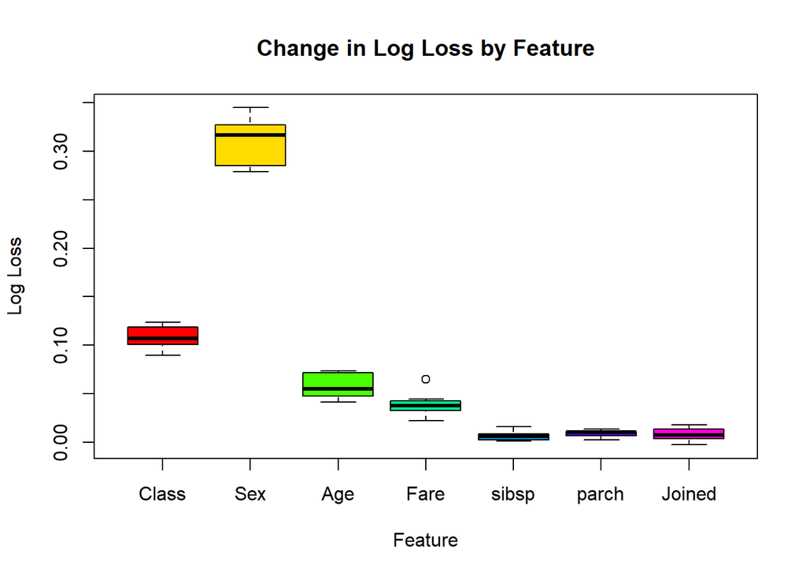

```r
avg_loss_df <- data.frame(avg_loss)
colnames(avg_loss_df) <- c('Class','Sex','Age','Fare','sibsp', 'parch', 'Joined')

boxplot(avg_loss_df,
        main = "Change in Log Loss by Feature",
        xlab = "Feature",
        ylab = "Log Loss",
        col = rainbow(ncol(avg_loss_df)))
```

## e. Method 3: Permute *before* fitting

For this approach, shuffle/permute the *training data* and re-fit the ensemble model. Evaluate the predictions on the (unaltered) test data. Repeat $M=10$ times (for each predictor variable) and produce a boxplot of the change in loss.

**Solution**

```r
avg_loss <- list()

for (i in 1:7){

  loss_change_list = vector()

  for (m in 1:10) {

    df_train_mod <- df_train
    df_train_mod[[i]] <- sample(df_train[[i]])

    rf_model <- ranger(Survived~.,num.trees=500, mtry=2, min.bucket=2,importance = "impurity", data=df_train_mod)

    pred <- predict(rf_model, data = df_test_mod)

    # calculate loss

    log_loss_df <- data.frame(df_test_mod$Survived, pred$pred)
    log_loss_df['eq'] <- (log_loss_df$df_test_mod.Survived * log(log_loss_df$pred.pred)) + ((1-log_loss_df$df_test_mod.Survived)*log(1-log_loss_df$pred.pred))

    log_loss <- ((-1/nrow(df_test_mod) )* sum(log_loss_df$eq)) - log_loss_c

    loss_change_list[[m]] <- log_loss

  }

  avg_loss[[i]] <- (loss_change_list)

}
```

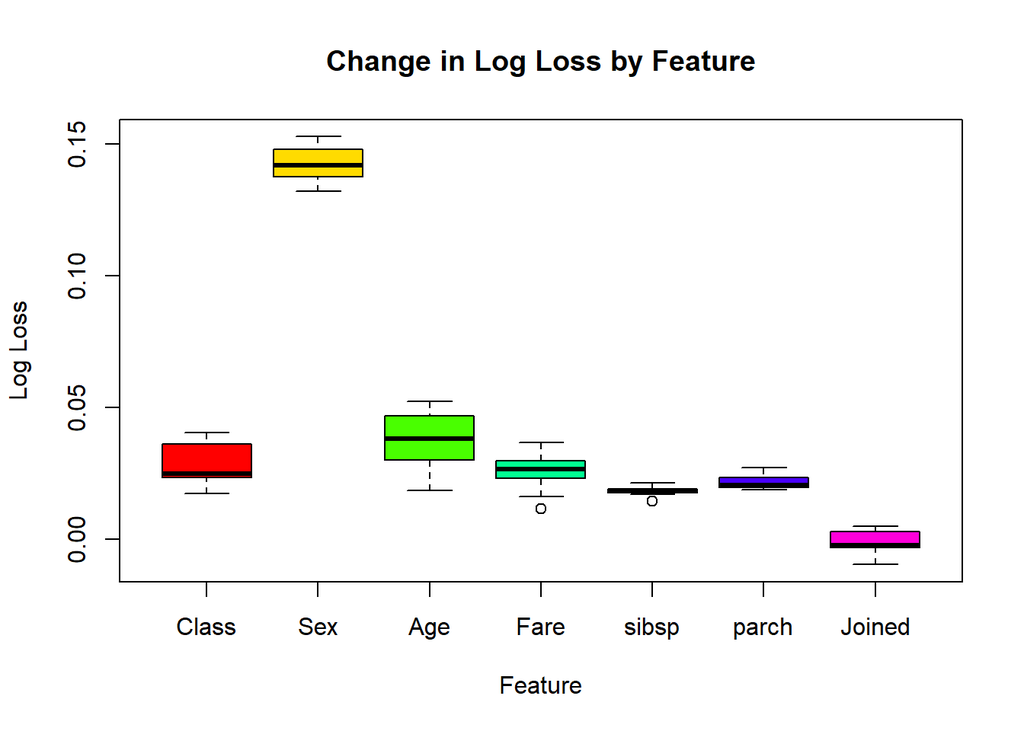

```r
avg_loss_df <- data.frame(avg_loss)
colnames(avg_loss_df) <- c('Class','Sex','Age','Fare','sibsp', 'parch', 'Joined')
boxplot(avg_loss_df,
        main = "Change in Log Loss by Feature",
        xlab = "Feature",
        ylab = "Log Loss",
        col = rainbow(ncol(avg_loss_df)))
```

## f. Understanding

Describe the benefits of each of the three approaches to measure feature importance.

**Solution**

Approach 1: Not computationally expensive

Approach 2: Allows us to see direct impact of test data, not as computationally expensive so more efficient

Approach 3: Prevents data leakage and more data available

# Problem 2: Effects of correlated predictors

This problem will illustrate what happens to the importance scores when there are highly associated predictors.

## a. Create an almost duplicate feature

Create a new feature `Sex2` that is 95% the same as `Sex`. Do this by selecting 5% of training ($n=50$) and testing ($n=15$) data and flip the `Sex` value.

```r
rand_numbers_train <- round(runif(n=50, min=1, max=1002), 0)
rand_numbers_test <- round(runif(n=15, min=1, max=296), 0)

df_train['Sex2'] <- df_train['Sex']
df_test['Sex2'] <- df_test['Sex']


df_train$Sex2[rand_numbers_train] <- ifelse(df_train$Sex2[rand_numbers_train] == 'male','female','male')
df_test$Sex2[rand_numbers_test] <- ifelse(df_test$Sex2[rand_numbers_test] == 'male','female','male')
```

## b. Method 1: Built-in importance

Fit the same model as in Problem 1b, but use the new data that includes `Sex2` (i.e., use both `Sex` and `Sex2` in the model). Calculate the built-in feature importance score and produce a barplot.

**Solution**

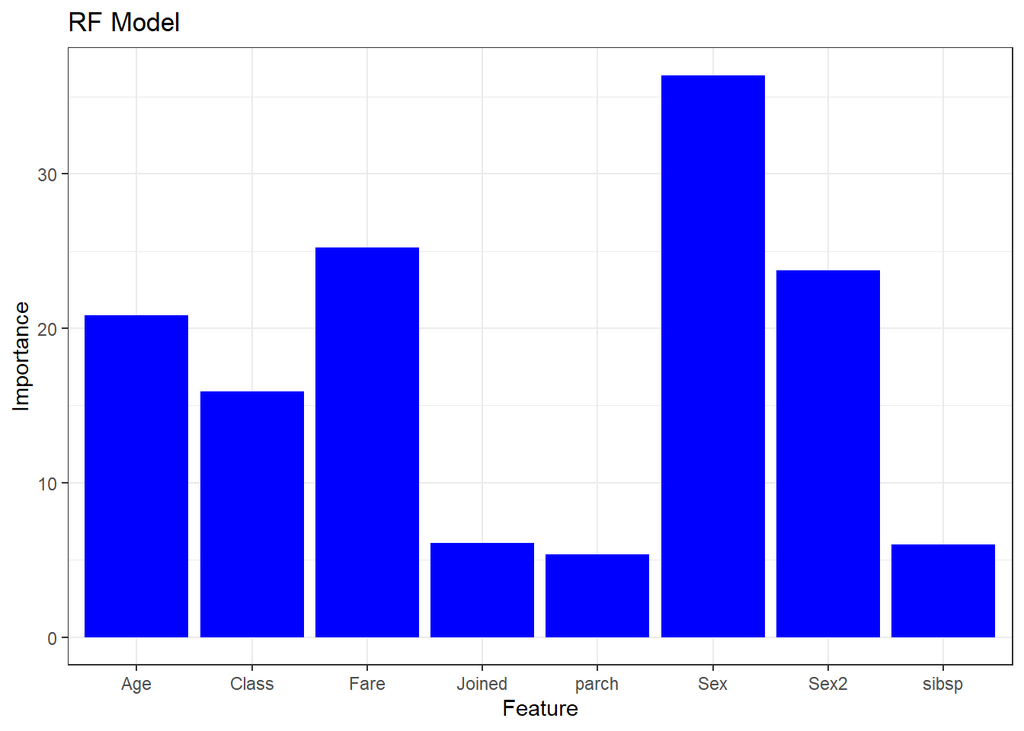

```r
rf_model <- ranger(Survived~.,num.trees=500, mtry=2, min.bucket=2,importance = "impurity", data=df_train)

import_df <- data.frame(Feature=names(rf_model$variable.importance), Importance = rf_model$variable.importance)

ggplot(data = import_df, aes(x=Feature, y = Importance)) +
  geom_col(fill='blue') +
  labs(title = 'RF Model', x = 'Feature', y = 'Importance')
```

## c. Method 2: Permute *after* fitting

Redo Method 2 (problem 1d) on the new data/model and produce a boxplot of importance scores. The importance score is defined as the difference in loss.

**Solution**

```r
df_train <- df_train[,c(1,2,3,4,5,6,7,9,8)]
df_test <- df_test[,c(1,2,3,4,5,6,7,9,8)]

avg_loss <- list()

for (i in 1:8){

  loss_change_list = vector()

  for (m in 1:10) {

    df_test_mod <- df_test
    df_test_mod[[i]] <- sample(df_test[[i]])

    pred <- predict(rf_model, data = df_test_mod)

    # calculate loss

    log_loss_df <- data.frame(df_test_mod$Survived, pred$pred)
  log_loss_df['eq'] <- (log_loss_df$df_test_mod.Survived * log(log_loss_df$pred.pred)) + ((1-log_loss_df$df_test_mod.Survived)*log(1-log_loss_df$pred.pred))

    log_loss <- ((-1/nrow(df_test_mod) )* sum(log_loss_df$eq)) - log_loss_c

    loss_change_list[[m]] <- log_loss

  }

  avg_loss[[i]] <- (loss_change_list)

}
```

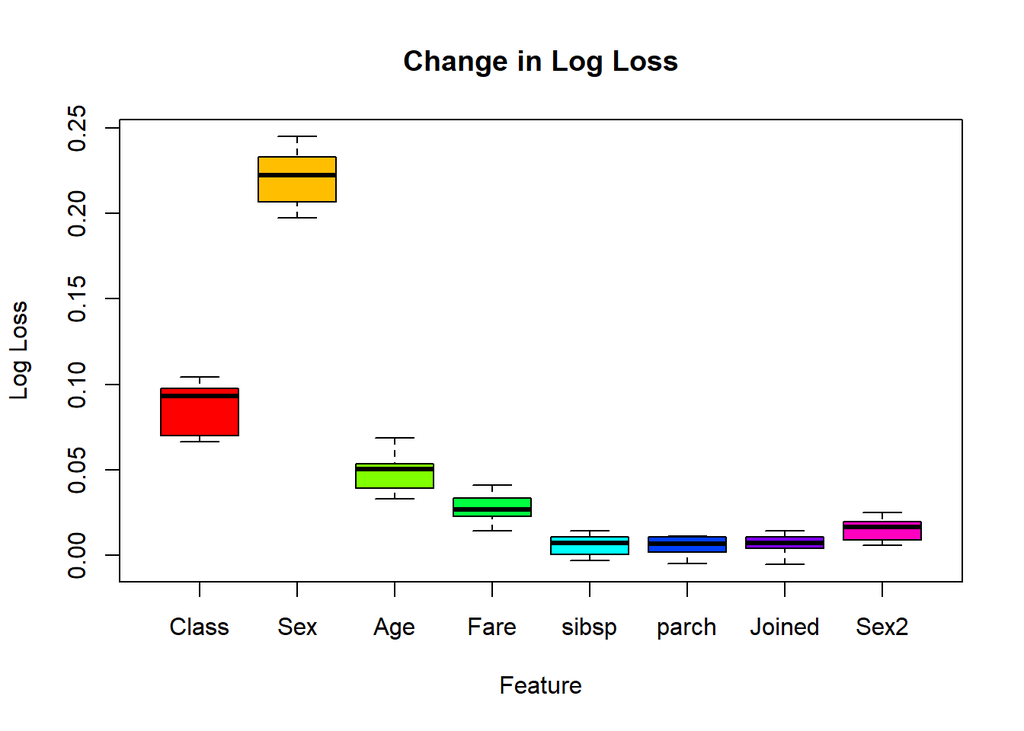

```r
avg_loss_df <- data.frame(avg_loss)
colnames(avg_loss_df) <- c('Class','Sex','Age','Fare','sibsp', 'parch', 'Joined', 'Sex2')

boxplot(avg_loss_df,
        main = "Change in Log Loss",
        xlab = "Feature",
        ylab = "Log Loss",
        col = rainbow(ncol(avg_loss_df)))
```

## d. Method 3: Permute *before* fitting

Redo Method 3 (problem 1e) on the new data and produce a boxplot of importance scores. The importance score is defined as the difference in loss.

**Solution**

```r
avg_loss <- list()

for (i in 1:8){

  loss_change_list = vector()

  for (m in 1:10) {

    df_train_mod <- df_train
    df_train_mod[[i]] <- sample(df_train[[i]])

    rf_model <- ranger(Survived~.,num.trees=500, mtry=2, min.bucket=2,importance = "impurity", data=df_train_mod)

    pred <- predict(rf_model, data = df_test_mod)

    # calculate loss

    log_loss_df <- data.frame(df_test_mod$Survived, pred$pred)
  log_loss_df['eq'] <- (log_loss_df$df_test_mod.Survived * log(log_loss_df$pred.pred)) + ((1-log_loss_df$df_test_mod.Survived)*log(1-log_loss_df$pred.pred))

    log_loss <- ((-1/nrow(df_test_mod) )* sum(log_loss_df$eq)) - log_loss_c

    loss_change_list[[m]] <- log_loss

  }

  avg_loss[[i]] <- (loss_change_list)

}
```

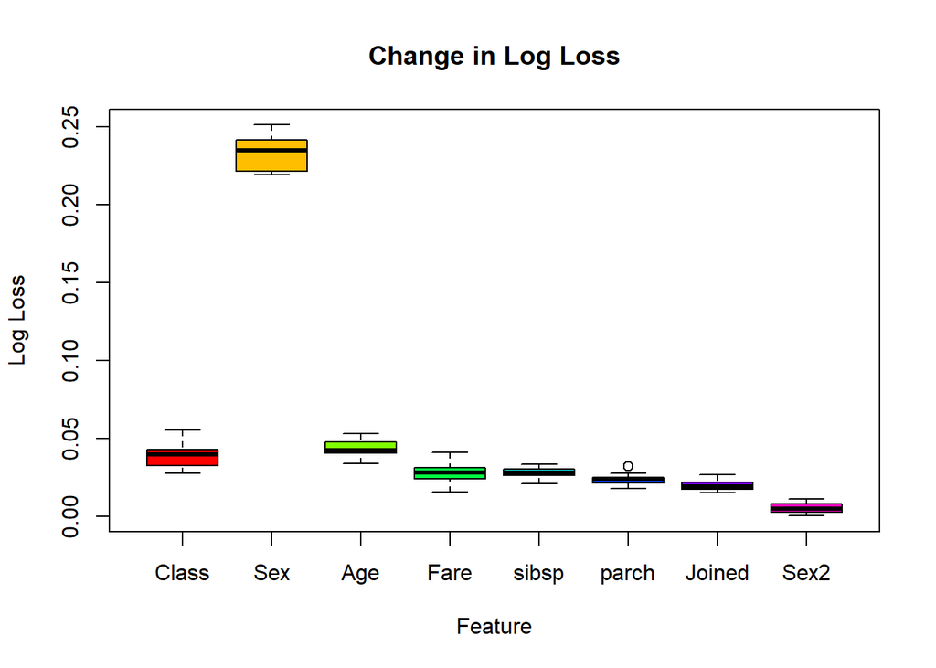

```r
avg_loss_df <- data.frame(avg_loss)
colnames(avg_loss_df) <- c('Class','Sex','Age','Fare','sibsp', 'parch', 'Joined', 'Sex2')

boxplot(avg_loss_df,
        main = "Change in Log Loss",
        xlab = "Feature",
        ylab = "Log Loss",
        col = rainbow(ncol(avg_loss_df)))
```

## e. Understanding

Describe how the addition of the almost duplicated predictor impacted the feature importance results.